# 0004_optimise_dense_structure

Dan MacLean

2018-06-21

## Manually normalise data

Following the document `0003_optimise_dense_structure` I have a decent model with 87 % accuracy on true test data. This is acceptable, but I wondered about the effect of manually normalising my input data. That is, scaling each row in a single sample such that the mean was 0 and the SD 1 and running the model on it. The smaller numbers here could have an effect on the training.

With this in mind, I have developed a new normalised data set `data/scaled_arab_TF.RDS` which can be built as

```bash
rake data/scaled_arab_TF.RDS
```

So I’ll use this in a similar experiemnt to `0003_optimise_dense_structure`

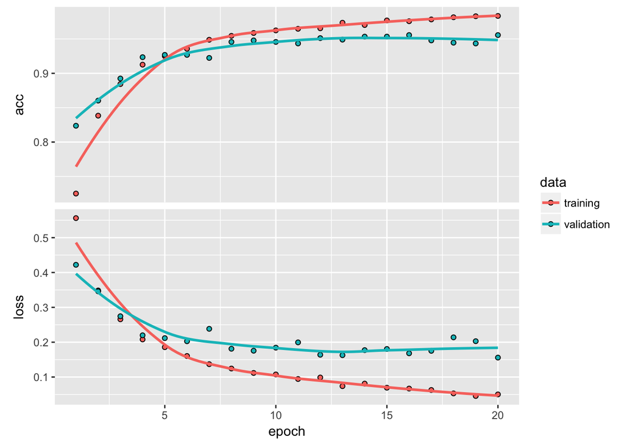

```r
make_model <- function(structure = list( layers=3, nodes_per_layer = c(16,16,32) ),
                       with_dropout = TRUE,
                       dropout_rate = 0.5,
                       with_l1 = FALSE,
                       l1_rate = 0.001,
                       with_l2 = FALSE,
                       l2_rate = 0.001
                       ){


  mod <- keras_model_sequential() %>%
    layer_dense(units = structure$nodes_per_layer[1], activation = "relu", input_shape = c(2, 232))

  for (l in 2:structure$layers){
    if (with_l1 ){
      mod <-mod  %>%
        layer_dense(units = structure$nodes_per_layer[l], kernel_regularizer = regularizer_l1(l1_rate) )
    }
    else if (with_l2){
      mod <-mod  %>%
        layer_dense(units = structure$nodes_per_layer[l], kernel_regularizer = regularizer_l2(l2_rate) )
    }
    else{
      mod <-mod  %>%
        layer_dense(units = structure$nodes_per_layer[l] )
    }

     if (with_dropout & (l < (structure$layers - 1))) { #no dropout after last layer
        mod <- mod %>% layer_dropout(rate = dropout_rate)
     }
  }

  mod <-mod %>%
    layer_flatten() %>%
    layer_dense(units = 1, activation = "sigmoid")

  mod %>% compile(
    optimizer = "rmsprop",
    loss = "binary_crossentropy",
    metrics = c("accuracy")
  )
  mod
}

arab_data <- readRDS("../data/scaled_arab_TF.RDS")
new_order <- sample(1:8704)
shuffled_data <- list(
  x = arab_data$x[new_order,,],
  y = as.numeric(arab_data$y[new_order])
)

train_i <- 1:6900
val_i <- 6901:7802
test_i <- 7803:8704

x_train <- shuffled_data$x[train_i,,]
x_val <- shuffled_data$x[val_i,,]
x_test <- shuffled_data$x[test_i,,]

y_train <- shuffled_data$y[train_i]
y_val <- shuffled_data$y[val_i]
y_test <- shuffled_data$y[test_i]

mod1_struct = list( layers = 12, nodes_per_layer = c(32,32,16,8,8,8,4,4,4,4,2,2))
model1 <- make_model(structure = mod1_struct, with_dropout = FALSE )

history1 <- model1 %>% fit(
  x_train,
  y_train,
  epochs = 20,
  batch_size = 512,
  validation_data = list(x_val, y_val)
)

plot(history1)
```

Ok, so we get to about 0.925 % accuracy before we start overfitting. Which is a good improvement! Let’s try fiddling with droput again and see how it goes. I’ll drop right back on the epochs as this model is training so quickly.

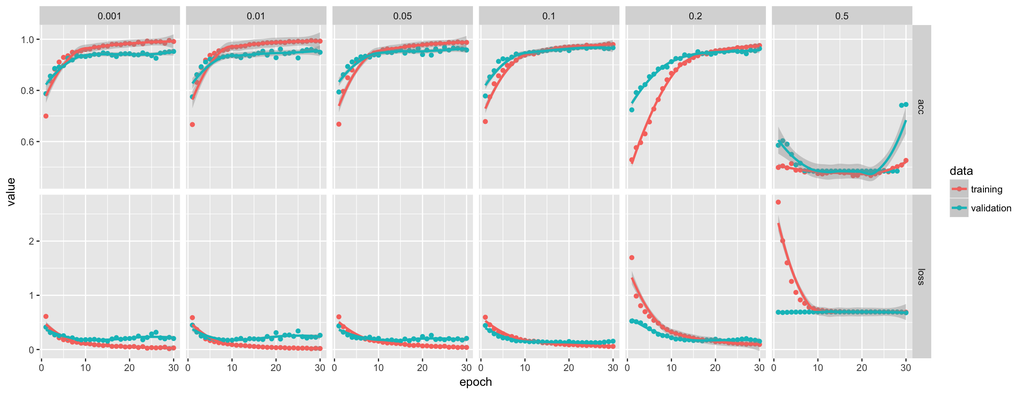

```r
result <- data.frame(dropout = double(), epoch = integer(), value = double(), metric = character(), data = character() )

for (dr in c(0.001, 0.01, 0.05, 0.1, 0.2, 0.5 )){
  epochs <- 30
  m <- make_model(structure = mod1_struct, with_dropout = TRUE, dropout_rate = dr )
  h <- m %>% fit(
      x_train,
      y_train,
      epochs = epochs,
      batch_size = 512,
      validation_data = list(x_val, y_val)
  )
  df_h <- as.data.frame( h )
  df_h$dropout <- rep(dr, epochs)
  result <- dplyr::bind_rows(result, df_h)

}

ggplot(result) + aes(epoch, value) + geom_point(aes(colour = data) ) + geom_smooth(aes(colour = data)) + facet_grid(metric ~ dropout, scales = "free")
```

This works really well with a slight dropout. 0.01 is getting us to 0.95 accuracy at about 5 epochs, which is really quick.

## Weight Regularization

Adding slight weight regularization can reduce overfitting, hopefully help us move inter an uber high accuracy bracket. Let’s try the same model with the best dropout and an l1 rate of 0.01

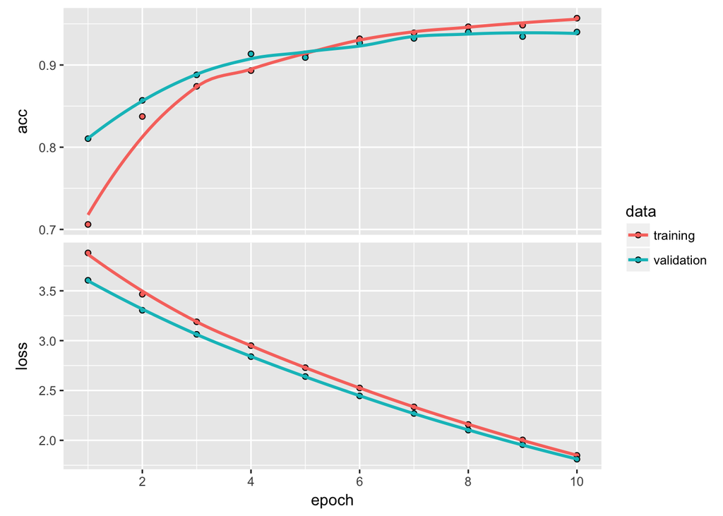

```r
m <- make_model(structure = mod1_struct, with_dropout = TRUE, dropout_rate = 0.01, with_l1 = TRUE, l1_rate = 0.01)

h <- m %>% fit(
      x_train,
      y_train,
      epochs = 10,
      batch_size = 512,
      validation_data = list(x_val, y_val)
)

plot(h)
```

Ok, so maybe not much improvement. Let’s try a range of l1s and see.

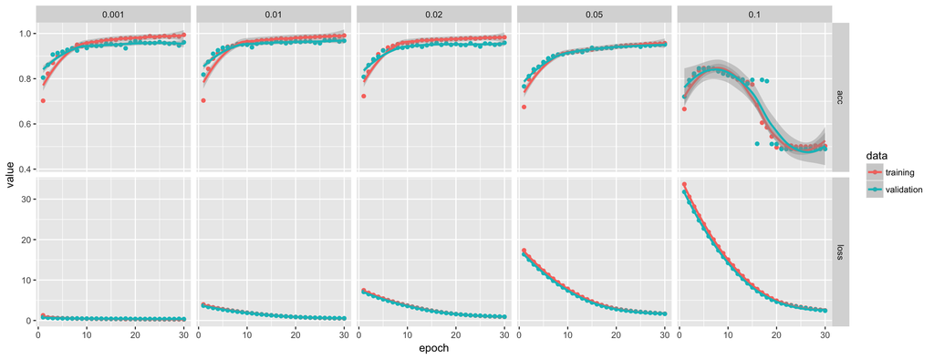

```r
result_l1 <- data.frame(l1 = double(), epoch = integer(), value = double(), metric = character(), data = character() )

for (l1 in c(0.001, 0.01, 0.02, 0.05, 0.1 )){
  epochs <- 30
  m <- make_model(structure = mod1_struct, with_dropout = TRUE, dropout_rate = 0.001, with_l1 = TRUE, l1_rate = l1)

  h <- m %>% fit(
      x_train,
      y_train,
      epochs = epochs,
      batch_size = 512,
      validation_data = list(x_val, y_val)
  )
  df_h <- as.data.frame( h )
  df_h$l1 <- rep(l1, epochs)
  result_l1 <- dplyr::bind_rows(result_l1, df_h)


}

ggplot(result_l1) + aes(epoch, value) + geom_point(aes(colour = data) ) + geom_smooth(aes(colour = data)) + facet_grid(metric ~ l1, scales = "free")
```

So big l1s are bad, but the lowest here isn’t having that much improvement. Not a big win with L1 regularization.

Quick check for L2.

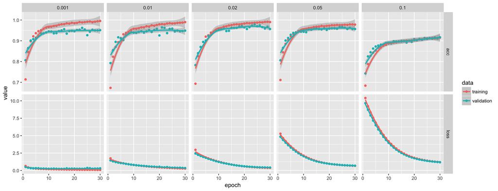

```r
result_l2 <- data.frame(l1 = double(), epoch = integer(), value = double(), metric = character(), data = character() )

for (l2 in c(0.001, 0.01, 0.02, 0.05, 0.1 )){
  epochs <- 30
  m <- make_model(structure = mod1_struct, with_dropout = TRUE, dropout_rate = 0.001, with_l2 = TRUE, l2_rate = l2)

  h <- m %>% fit(
      x_train,
      y_train,
      epochs = epochs,
      batch_size = 512,
      validation_data = list(x_val, y_val)
  )
  df_h <- as.data.frame( h )
  df_h$l2 <- rep(l2, epochs)
  result_l2 <- dplyr::bind_rows(result_l2, df_h)


}

ggplot(result_l2) + aes(epoch, value) + geom_point(aes(colour = data) ) + geom_smooth(aes(colour = data)) + facet_grid(metric ~ l2, scales = "free")
```

Same. No advances. So with no other optimisation to perform for this sort of network I’ll stick with the structure and dropout.

## Final Test

Having built a model, we can retrain and get final assessment by running on the test data.

```r
m <- make_model(structure = mod1_struct, with_dropout = TRUE, dropout_rate = 0.001)
  h <- m %>% fit(
      x_train,
      y_train,
      epochs = 5,
      batch_size = 512
  )

result <- m %>% evaluate(x_test, y_test)
result
```

```
## $loss
## [1] 0.1600016
##
## $acc
## [1] 0.9334812
```